# 重賞レース予測レポート【毎時自動更新中】

作成日時: 2025/12/07 16:06:33

☞ [マニュアル(pdf)](https://ryutoro-galois.github.io/keiba-predictor/manual/manual.pdf)

☞ 過去5年の同一レース結果: [2024年](https://ryutoro-galois.github.io/keiba-predictor/report/PredResult_2024y_raceDate_20241130_20241201.html), [2023年](https://ryutoro-galois.github.io/keiba-predictor/report/PredResult_2023y_raceDate_20231202_20231203.html), [2022年](https://ryutoro-galois.github.io/keiba-predictor/report/PredResult_2022y_raceDate_20221203_20221204.html), [2021年](https://ryutoro-galois.github.io/keiba-predictor/report/PredResult_2021y_raceDate_20211204_20211205.html), [2020年](https://ryutoro-galois.github.io/keiba-predictor/report/PredResult_2020y_raceDate_20201205_20201206.html)

☞ 過去4週間の別レース結果: [1週前(11/29-30)](https://ryutoro-galois.github.io/keiba-predictor/report/PredResult_2025y_raceDate_20251129_20251130.html), [2週前(11/22-24)](https://ryutoro-galois.github.io/keiba-predictor/report/PredResult_2025y_raceDate_20251122_20251124.html), [3週前(11/15-16)](https://ryutoro-galois.github.io/keiba-predictor/report/PredResult_2025y_raceDate_20251115_20251116.html), [4週前(11/8-9)](https://ryutoro-galois.github.io/keiba-predictor/report/PredResult_2025y_raceDate_20251108_20251109.html)

☞ netkeiba: [ステイヤーズステークス(GⅡ)](https://race.netkeiba.com/race/shutuba.html?race_id=202506050111&rf=race_list), [鳴尾記念(GⅢ)](https://race.netkeiba.com/race/shutuba.html?race_id=202509050111&rf=race_list), [チャンピオンズカップ(GⅠ)](https://race.netkeiba.com/race/shutuba.html?race_id=202507050211&rf=race_list)

## 0. 推し馬予測 (AI予測)

### 【ステイヤーズステークス(GⅡ) 2025/12/06(土)】

- 本命(◎): 1-3着内確率(勝負強さ)が1位の馬
- 対抗(◯): 1-3着内確率が2-N位(20%程度以上)の中で予測タイムが最も速い馬
- 3番手(▲): 1-3着内確率が2-N位(20%程度以上)のでダークホース確率が最も高い馬
- 穴: ダークホース確率が上位1-M位(40%程度以上)の中で1-3着内確率が最も高い馬

| 推し馬 | 枠番 | 馬番 | 人気 | オッズ | 馬名 | 騎手 | 調教師 | 予測タイム(sec) | 1_順位 | 1-3着内確率(%) | 2_順位 | ﾀﾞｰｸﾎｰｽ確率(%) | 3_順位 |
| --- | --- | --- | --- | --- | --- | --- | --- | --- | --- | --- | --- | --- | --- |
| 本命(◎) | 5 | 7 | 1 | 3.5 | クロミナンス | Ｃ．ルメール | 尾関知人 | 223.0 | 1.5 | 27.5 | 1 | 0.5 | 12 |
| 対抗(◯) | 3 | 3 | 2 | 4.4 | ホーエリート | 戸崎圭太 | 田島俊明 | 223.0 | 1.5 | 20.9 | 4 | 0.5 | 9 |
| 穴 | 4 | 6 | 13 | 78.1 | ミクソロジー | 石川裕紀人 | 辻野泰之 | 227.6 | 3.0 | 5.7 | 12 | 62.1 | 1 |

### 【鳴尾記念(GⅢ) 2025/12/06(土)】

- 本命(◎): 1-3着内確率(勝負強さ)が1位の馬
- 対抗(◯): 1-3着内確率が2-N位(20%程度以上)の中で予測タイムが最も速い馬
- 3番手(▲): 1-3着内確率が2-N位(20%程度以上)のでダークホース確率が最も高い馬
- 穴: ダークホース確率が上位1-M位(40%程度以上)の中で1-3着内確率が最も高い馬

| 推し馬 | 枠番 | 馬番 | 人気 | オッズ | 馬名 | 騎手 | 調教師 | 予測タイム(sec) | 1_順位 | 1-3着内確率(%) | 2_順位 | ﾀﾞｰｸﾎｰｽ確率(%) | 3_順位 |
| --- | --- | --- | --- | --- | --- | --- | --- | --- | --- | --- | --- | --- | --- |
| 本命(◎) | 8 | 14 | 4 | 8.1 | オールナット | 北村友一 | 高野友和 | 121.3 | 6 | 50.0 | 1 | 0.7 | 12 |
| 対抗(◯) | 3 | 4 | 7 | 17.7 | センツブラッド | 坂井瑠星 | 斉藤崇史 | 119.6 | 2 | 23.7 | 3 | 1.8 | 8 |
| 3番手(▲) | 6 | 9 | 6 | 10.9 | ウエストナウ | 団野大成 | 佐々木晶三 | 120.4 | 4 | 30.9 | 2 | 1.5 | 9 |
| 穴 | 7 | 11 | 9 | 24.2 | ドゥラエレーデ | 西村淳也 | 池添学 | 124.4 | 12 | 16.0 | 7 | 18.7 | 4 |

### 【チャンピオンズカップ(GⅠ) 2025/12/07(日)】

- 本命(◎): 1-3着内確率(勝負強さ)が1位の馬
- 対抗(◯): 1-3着内確率が2-N位(20%程度以上)の中で予測タイムが最も速い馬
- 3番手(▲): 1-3着内確率が2-N位(20%程度以上)のでダークホース確率が最も高い馬
- 穴: ダークホース確率が上位1-M位(40%程度以上)の中で1-3着内確率が最も高い馬

| 推し馬 | 枠番 | 馬番 | 人気 | オッズ | 馬名 | 騎手 | 調教師 | 予測タイム(sec) | 1_順位 | 1-3着内確率(%) | 2_順位 | ﾀﾞｰｸﾎｰｽ確率(%) | 3_順位 |
| --- | --- | --- | --- | --- | --- | --- | --- | --- | --- | --- | --- | --- | --- |
| 本命(◎) | 1 | 2 | 3 | 7.3 | ダブルハートボンド | 坂井瑠星 | 大久保龍志 | 112.2 | 3.0 | 34.6 | 1 | 4.0 | 9 |
| 対抗(◯) | 2 | 4 | 14 | 155.6 | セラフィックコール | 西村淳也 | 寺島良 | 110.1 | 1.5 | 28.0 | 5 | 75.7 | 1 |
| 3番手(▲) | 6 | 12 | 1 | 2.2 | ナルカミ | 戸崎圭太 | 田中博康 | 110.1 | 1.5 | 26.3 | 6 | 3.9 | 10 |
| 穴 | 5 | 10 | 10 | 55.6 | テンカジョウ | 国分優作 | 岡田稲男 | 114.2 | 4.0 | 16.5 | 8 | 51.9 | 4 |

## 1. 予測チャート (タイム/勝負強さ)

### 【ステイヤーズステークス(GⅡ)】

2025/12/06(土), 06_中山, 芝右内2周3600m

[interactive chart not shown]

### 【鳴尾記念(GⅢ)】

[interactive chart not shown]

### 【チャンピオンズカップ(GⅠ)】

2025/12/07(日), 07_中京, ダ左1800m

[interactive chart not shown]

## 2. オッズモニタリング (毎時)

### 【ステイヤーズステークス】

[interactive chart not shown]

### 【鳴尾記念】

[interactive chart not shown]

### 【チャンピオンズカップ】

[interactive chart not shown]

## 3. 出馬表

### 【ステイヤーズステークス 2025/12/06(土) 】

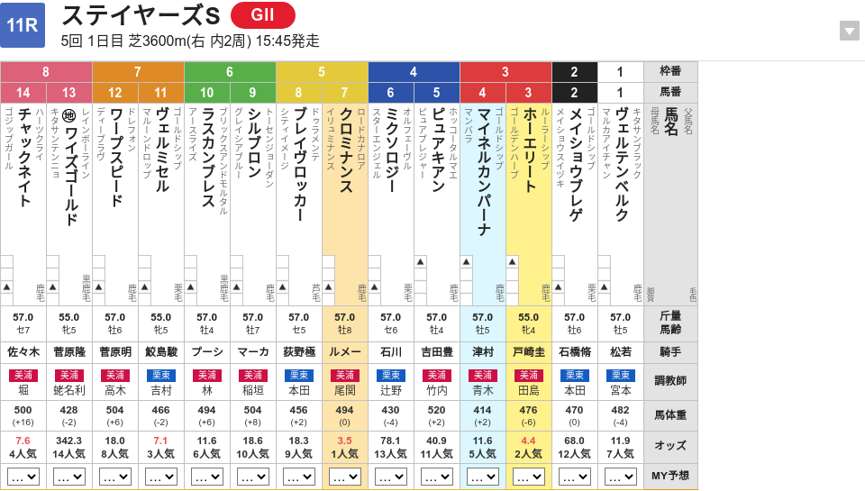

### 【鳴尾記念 2025/12/06(土) 】

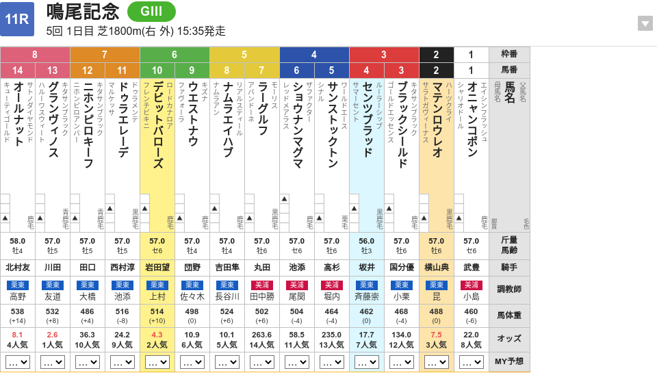

### 【チャンピオンズカップ 2025/12/07(日) 】

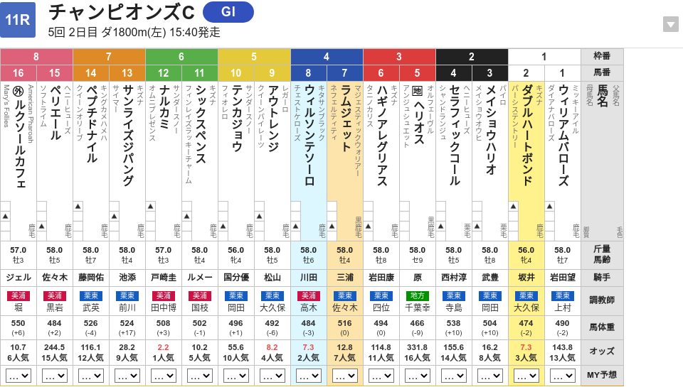

## 4. 単勝予測結果

### 【ステイヤーズステークス(GⅡ) 2025/12/06(土)】

| 枠番 | 馬番 | 人気 | オッズ | 馬名 | 騎手 | 調教師 | 予測タイム(sec) | 1_順位 | 1-3着内確率(%) | 2_順位 | ﾀﾞｰｸﾎｰｽ確率(%) | 3_順位 |
| --- | --- | --- | --- | --- | --- | --- | --- | --- | --- | --- | --- | --- |
| 1 | 1 | 7 | 11.9 | ヴェルテンベルク | 松若風馬 | 宮本博 | 237.5 | 13.0 | 22.0 | 3 | 0.5 | 10 |
| 2 | 2 | 12 | 68.0 | メイショウブレゲ | 石橋脩 | 本田優 | 236.8 | 11.0 | 3.5 | 14 | 16.1 | 5 |
| 3 | 3 | 2 | 4.4 | ホーエリート | 戸崎圭太 | 田島俊明 | 223.0 | 1.5 | 20.9 | 4 | 0.5 | 9 |
| 3 | 4 | 5 | 11.6 | マイネルカンパーナ | 津村明秀 | 青木孝文 | 235.9 | 7.0 | 25.5 | 2 | 0.5 | 11 |
| 4 | 5 | 11 | 40.9 | ピュアキアン | 吉田豊 | 竹内正洋 | 237.2 | 12.0 | 9.1 | 10 | 16.1 | 4 |
| 4 | 6 | 13 | 78.1 | ミクソロジー | 石川裕紀人 | 辻野泰之 | 227.6 | 3.0 | 5.7 | 12 | 62.1 | 1 |
| 5 | 7 | 1 | 3.5 | クロミナンス | Ｃ．ルメール | 尾関知人 | 223.0 | 1.5 | 27.5 | 1 | 0.5 | 12 |
| 5 | 8 | 9 | 18.3 | ブレイヴロッカー | 荻野極 | 本田優 | 238.3 | 14.0 | 10.8 | 8 | 26.0 | 3 |
| 6 | 9 | 10 | 18.6 | シルブロン | Ｔ．マーカンド | 稲垣幸雄 | 235.9 | 6.0 | 10.8 | 9 | 13.6 | 7 |
| 6 | 10 | 6 | 11.6 | ラスカンブレス | Ａ．プーシャン | 林徹 | 236.0 | 8.0 | 18.7 | 6 | 0.4 | 14 |

[output cut: 4 more lines]

### 【鳴尾記念(GⅢ) 2025/12/06(土)】

| 枠番 | 馬番 | 人気 | オッズ | 馬名 | 騎手 | 調教師 | 予測タイム(sec) | 1_順位 | 1-3着内確率(%) | 2_順位 | ﾀﾞｰｸﾎｰｽ確率(%) | 3_順位 |
| --- | --- | --- | --- | --- | --- | --- | --- | --- | --- | --- | --- | --- |
| 1 | 1 | 8 | 22.0 | オニャンコポン | 武豊 | 小島茂之 | 124.5 | 13 | 12.0 | 9 | 11.3 | 6 |
| 2 | 2 | 3 | 7.5 | マテンロウレオ | 横山典弘 | 昆貢 | 123.2 | 11 | 20.0 | 5 | 0.8 | 11 |
| 3 | 3 | 12 | 134.0 | ブラックシールド | 国分優作 | 小栗実 | 120.2 | 3 | 14.1 | 8 | 39.7 | 1 |
| 3 | 4 | 7 | 17.7 | センツブラッド | 坂井瑠星 | 斉藤崇史 | 119.6 | 2 | 23.7 | 3 | 1.8 | 8 |
| 4 | 5 | 13 | 235.0 | サンストックトン | 高杉吏麒 | 堀内岳志 | 122.6 | 10 | 6.3 | 12 | 29.2 | 3 |
| 4 | 6 | 11 | 58.5 | ショウナンマグマ | 池添謙一 | 尾関知人 | 121.5 | 7 | 3.9 | 14 | 5.3 | 7 |
| 5 | 7 | 14 | 263.6 | ラーグルフ | 丸田恭介 | 田中勝春 | 122.5 | 8 | 5.2 | 13 | 17.2 | 5 |
| 5 | 8 | 5 | 10.1 | ナムラエイハブ | 吉田隼人 | 長谷川浩大 | 122.5 | 9 | 20.6 | 4 | 1.2 | 10 |
| 6 | 9 | 6 | 10.9 | ウエストナウ | 団野大成 | 佐々木晶三 | 120.4 | 4 | 30.9 | 2 | 1.5 | 9 |
| 6 | 10 | 2 | 4.3 | デビットバローズ | 岩田望来 | 上村洋行 | 121.2 | 5 | 16.5 | 6 | 0.3 | 14 |

[output cut: 4 more lines]

### 【チャンピオンズカップ(GⅠ) 2025/12/07(日)】

| 枠番 | 馬番 | 人気 | オッズ | 馬名 | 騎手 | 調教師 | 予測タイム(sec) | 1_順位 | 1-3着内確率(%) | 2_順位 | ﾀﾞｰｸﾎｰｽ確率(%) | 3_順位 |
| --- | --- | --- | --- | --- | --- | --- | --- | --- | --- | --- | --- | --- |
| 1 | 1 | 13 | 143.8 | ウィリアムバローズ | 岩田望来 | 上村洋行 | 118.5 | 15.0 | 7.8 | 13 | 16.7 | 7 |
| 1 | 2 | 3 | 7.3 | ダブルハートボンド | 坂井瑠星 | 大久保龍志 | 112.2 | 3.0 | 34.6 | 1 | 4.0 | 9 |
| 2 | 3 | 8 | 16.2 | メイショウハリオ | 武豊 | 岡田稲男 | 117.2 | 11.0 | 14.3 | 9 | 2.2 | 14 |
| 2 | 4 | 14 | 155.6 | セラフィックコール | 西村淳也 | 寺島良 | 110.1 | 1.5 | 28.0 | 5 | 75.7 | 1 |
| 3 | 5 | 16 | 331.8 | ヘリオス | 原優介 | 千葉幸喜 | 115.4 | 6.0 | 9.5 | 11 | 24.1 | 5 |
| 3 | 6 | 11 | 114.8 | ハギノアレグリアス | 岩田康誠 | 四位洋文 | 117.9 | 14.0 | 10.9 | 10 | 52.7 | 3 |
| 4 | 7 | 7 | 12.8 | ラムジェット | 三浦皇成 | 佐々木晶三 | 116.6 | 9.0 | 20.3 | 7 | 2.1 | 15 |
| 4 | 8 | 2 | 7.3 | ウィルソンテソーロ | 川田将雅 | 高木登 | 115.9 | 7.0 | 31.2 | 3 | 2.7 | 13 |
| 5 | 9 | 4 | 8.2 | アウトレンジ | 松山弘平 | 大久保龍志 | 116.3 | 8.0 | 28.8 | 4 | 3.4 | 11 |
| 5 | 10 | 10 | 55.6 | テンカジョウ | 国分優作 | 岡田稲男 | 114.2 | 4.0 | 16.5 | 8 | 51.9 | 4 |

[output cut: 5 more lines]

## 5. 人気と着順の乖離率推移

### 【ステイヤーズステークス_1990y_2019y】

[interactive chart not shown]

### 【鳴尾記念_1990y_2019y】

[interactive chart not shown]

### 【チャンピオンズカップ_2014y_2019y】

[interactive chart not shown]

### 【ステイヤーズステークス_1990y_2019y】

| No | 開催年 | 不整合率(%) | 頭数 | 人気別着順(1-3位) | 人気別着順(全体) |
| --- | --- | --- | --- | --- | --- |
| 30 | 2019 | 49.7 | 13頭 | 6-1-11 | 6\|1\|11\|5\|7\|4\|3\|9\|12\|8\|2\|10\|13 |
| 29 | 2018 | 16.9 | 13頭 | 1-2-4 | 1\|2\|4\|9\|11\|5\|6\|7\|10\|12\|3\|8\|13 |
| 28 | 2017 | 5.0 | 10頭 | 1-2-3 | 1\|2\|3\|8\|4\|6\|5\|10\|7\|9 |
| 27 | 2016 | 20.8 | 13頭 | 1-3-2 | 1\|3\|2\|7\|6\|4\|8\|5\|10\|9\|11\|12\|13 |
| 26 | 2015 | 26.2 | 16頭 | 1-7-4 | 1\|7\|4\|13\|6\|2\|3\|5\|14\|12\|10\|15\|9\|16\|11\|8 |
| 25 | 2014 | 41.5 | 15頭 | 3-4-1 | 3\|4\|1\|6\|2\|10\|12\|15\|8\|5\|7\|9\|14\|13\|11 |
| 24 | 2013 | 44.0 | 13頭 | 1-4-7 | 1\|4\|7\|8\|6\|5\|3\|2\|13\|11\|9\|12\|10 |
| 23 | 2012 | 47.9 | 14頭 | 8-4-2 | 8\|4\|2\|11\|9\|15\|7\|1\|6\|3\|14\|10\|5\|13 |
| 22 | 2011 | 57.3 | 16頭 | 4-6-12 | 4\|6\|12\|10\|2\|11\|3\|8\|7\|16\|1\|13\|14\|9\|15\|5 |
| 21 | 2010 | 48.6 | 15頭 | 5-2-3 | 5\|2\|3\|6\|4\|11\|10\|7\|1\|12\|9\|15\|8\|14\|13 |

[output cut: 20 more lines]

### 【鳴尾記念_1990y_2019y】

| No | 開催年 | 不整合率(%) | 頭数 | 人気別着順(1-3位) | 人気別着順(全体) |
| --- | --- | --- | --- | --- | --- |
| 29 | 2019 | 26.9 | 9頭 | 1-5-4 | 1\|5\|4\|2\|6\|7\|8\|3\|9 |
| 28 | 2018 | 24.2 | 11頭 | 4-1-2 | 4\|1\|2\|3\|6\|9\|8\|7\|11\|5\|10 |
| 27 | 2017 | 46.8 | 10頭 | 3-1-7 | 3\|1\|7\|5\|10\|4\|2\|6\|9\|8 |
| 26 | 2016 | 49.3 | 14頭 | 3-2-13 | 3\|2\|13\|4\|7\|1\|8\|5\|11\|14\|12\|9\|10\|6 |
| 25 | 2015 | 33.9 | 11頭 | 2-8-4 | 2\|8\|4\|1\|3\|6\|7\|10\|9\|5\|11 |
| 24 | 2014 | 24.9 | 12頭 | 1-9-10 | 1\|9\|10\|2\|11\|6\|5\|4\|3\|12\|7\|8 |
| 23 | 2013 | 56.2 | 15頭 | 6-7-3 | 6\|7\|3\|4\|12\|1\|14\|8\|5\|2\|13\|11\|15\|10\|9 |
| 22 | 2012 | 28.8 | 10頭 | 2-1-5 | 2\|1\|5\|4\|3\|8\|10\|6\|7\|9 |
| 21 | 2011 | 30.1 | 13頭 | 4-6-1 | 4\|6\|1\|2\|7\|9\|11\|3\|8\|5\|12\|10\|13 |
| 20 | 2010 | 27.2 | 12頭 | 2-1-4 | 2\|1\|4\|5\|7\|10\|9\|3\|11\|6\|8\|12 |

[output cut: 19 more lines]

### 【チャンピオンズカップ_2014y_2019y】

| No | 開催年 | 不整合率(%) | 頭数 | 人気別着順(1-3位) | 人気別着順(全体) |
| --- | --- | --- | --- | --- | --- |
| 6 | 2019 | 20.6 | 16頭 | 2-1-3 | 2\|1\|3\|5\|13\|4\|10\|8\|6\|14\|11\|12\|15\|9\|7\|16 |
| 5 | 2018 | 31.8 | 15頭 | 1-8-3 | 1\|8\|3\|9\|4\|5\|6\|12\|11\|15\|2\|14\|10\|13\|7 |
| 4 | 2017 | 34.1 | 15頭 | 8-1-9 | 8\|1\|9\|3\|4\|12\|5\|11\|6\|10\|2\|14\|13\|15\|7 |
| 3 | 2016 | 39.2 | 15頭 | 6-1-10 | 6\|1\|10\|11\|7\|4\|5\|9\|8\|12\|14\|2\|3\|15\|13 |
| 2 | 2015 | 55.4 | 16頭 | 12-3-5 | 12\|3\|5\|8\|2\|14\|1\|10\|7\|16\|15\|9\|13\|4\|11\|6 |
| 1 | 2014 | 47.5 | 16頭 | 2-8-3 | 2\|8\|3\|15\|5\|10\|14\|7\|13\|4\|9\|1\|12\|6\|11\|16 |

## 6. 1-3番人気馬の着順分類予測

### 【ステイヤーズステークス】

| 分類 | 凡例 | 発生確率(%) | 当該レース | 当該レースランク | 直近1年間 |
| --- | --- | --- | --- | --- | --- |
| 1: 1番人気のみ (1_pop1) | 1 \| * \| * | 19.1 | 0.51 | 0.51 | 0.29 |
| 4: 1,2番人気のみ (4_pop12) | 1 \| 2 \| * | 16.9 | 0.84 | 1.25 | 0.00 |
| 5: 1,3番人気のみ (5_pop13) | 1 \| 3 \| * | 14.1 | 0.99 | 0.87 | 0.00 |
| 8: 1,2,3番人気すべて着外 (8_darkhorse) | * \| * \| * | 13.6 | 2.39 | 1.26 | 0.00 |
| 2: 2番人気のみ (2_pop2) | 2 \| * \| * | 10.1 | 0.89 | 0.75 | 0.00 |
| 3: 3番人気のみ (3_pop3) | 3 \| * \| * | 9.7 | 3.34 | 0.00 | 0.00 |
| 6: 2,3番人気のみ (6_pop23) | 2 \| 3 \| * | 9.1 | 3.14 | 3.37 | 0.00 |
| 7: 1,2,3番人気すべて着内 (7_pop123) | 1 \| 2 \| 3 | 7.4 | 1.30 | 1.37 | 0.22 |

### 【鳴尾記念】

| 分類 | 凡例 | 発生確率(%) | 当該レース | 当該レースランク | 直近1年間 |
| --- | --- | --- | --- | --- | --- |
| 1: 1番人気のみ (1_pop1) | 1 \| * \| * | 18.2 | 0.48 | 0.49 | 0.27 |
| 4: 1,2番人気のみ (4_pop12) | 1 \| 2 \| * | 16.6 | 1.13 | 0.76 | 0.00 |
| 8: 1,2,3番人気すべて着外 (8_darkhorse) | * \| * \| * | 14.3 | 1.62 | 4.61 | 0.00 |
| 5: 1,3番人気のみ (5_pop13) | 1 \| 3 \| * | 14.2 | 0.97 | 1.14 | 0.00 |
| 6: 2,3番人気のみ (6_pop23) | 2 \| 3 \| * | 10.1 | 3.48 | 3.26 | 0.00 |
| 2: 2番人気のみ (2_pop2) | 2 \| * \| * | 9.9 | 0.84 | 1.05 | 0.00 |
| 3: 3番人気のみ (3_pop3) | 3 \| * \| * | 9.5 | 1.61 | 1.01 | 0.00 |
| 7: 1,2,3番人気すべて着内 (7_pop123) | 1 \| 2 \| 3 | 7.3 | 2.52 | 2.35 | 0.22 |

### 【チャンピオンズカップ】

| 分類 | 凡例 | 発生確率(%) | 当該レース | 当該レースランク | 直近1年間 |
| --- | --- | --- | --- | --- | --- |
| 1: 1番人気のみ (1_pop1) | 1 \| * \| * | 19.1 | 1.05 | 1.05 | 0.00 |
| 4: 1,2番人気のみ (4_pop12) | 1 \| 2 \| * | 16.9 | 0.00 | 0.00 | 0.00 |
| 5: 1,3番人気のみ (5_pop13) | 1 \| 3 \| * | 14.1 | 1.55 | 1.55 | 0.00 |
| 8: 1,2,3番人気すべて着外 (8_darkhorse) | * \| * \| * | 13.6 | 0.00 | 0.00 | 0.00 |
| 2: 2番人気のみ (2_pop2) | 2 \| * \| * | 10.1 | 0.00 | 0.00 | 0.00 |
| 3: 3番人気のみ (3_pop3) | 3 \| * \| * | 9.7 | 1.07 | 1.07 | 0.00 |
| 6: 2,3番人気のみ (6_pop23) | 2 \| 3 \| * | 9.1 | 1.00 | 1.00 | 0.00 |
| 7: 1,2,3番人気すべて着内 (7_pop123) | 1 \| 2 \| 3 | 7.4 | 0.14 | 0.14 | 0.07 |

## 7. 3連複予測結果

### 【ステイヤーズステークス(GⅡ) 2025/12/06(土)】

| 分類 | 馬番 | 枠番 | 人気 | 平均予測タイム(sec) | 1-3着内確率(%) | ﾀﾞｰｸﾎｰｽ確率(%) | 馬名 | 騎手 | 調教師 |
| --- | --- | --- | --- | --- | --- | --- | --- | --- | --- |
| 1: 1番人気のみ (1_pop1) | 7-4-1 | 5-3-1 | 1-5-7 | 232.13 | 1.54 | 0.00 | クロミナンス \| マイネルカンパーナ \| ヴェルテンベルク | Ｃ．ルメール \| 津村明秀 \| 松若風馬 | 尾関知人 \| 青木孝文 \| 宮本博 |
| 4: 1,2番人気のみ (4_pop12) | 7-3-4 | 5-3-3 | 1-2-5 | 227.30 | 1.46 | 0.00 | クロミナンス \| ホーエリート \| マイネルカンパーナ | Ｃ．ルメール \| 戸崎圭太 \| 津村明秀 | 尾関知人 \| 田島俊明 \| 青木孝文 |
| 5: 1,3番人気のみ (5_pop13) | 7-11-4 | 5-7-3 | 1-3-5 | 231.57 | 1.35 | 0.00 | クロミナンス \| ヴェルミセル \| マイネルカンパーナ | Ｃ．ルメール \| 鮫島克駿 \| 津村明秀 | 尾関知人 \| 吉村圭司 \| 青木孝文 |
| 1: 1番人気のみ (1_pop1) | 7-4-10 | 5-3-6 | 1-5-6 | 231.63 | 1.31 | 0.00 | クロミナンス \| マイネルカンパーナ \| ラスカンブレス | Ｃ．ルメール \| 津村明秀 \| Ａ．プーシャン | 尾関知人 \| 青木孝文 \| 林徹 |
| 4: 1,2番人気のみ (4_pop12) | 7-3-1 | 5-3-1 | 1-2-7 | 227.83 | 1.26 | 0.00 | クロミナンス \| ホーエリート \| ヴェルテンベルク | Ｃ．ルメール \| 戸崎圭太 \| 松若風馬 | 尾関知人 \| 田島俊明 \| 宮本博 |
| 2: 2番人気のみ (2_pop2) | 3-4-1 | 3-3-1 | 2-5-7 | 232.13 | 1.17 | 0.00 | ホーエリート \| マイネルカンパーナ \| ヴェルテンベルク | 戸崎圭太 \| 津村明秀 \| 松若風馬 | 田島俊明 \| 青木孝文 \| 宮本博 |
| 5: 1,3番人気のみ (5_pop13) | 7-11-1 | 5-7-1 | 1-3-7 | 232.10 | 1.16 | 0.00 | クロミナンス \| ヴェルミセル \| ヴェルテンベルク | Ｃ．ルメール \| 鮫島克駿 \| 松若風馬 | 尾関知人 \| 吉村圭司 \| 宮本博 |
| 1: 1番人気のみ (1_pop1) | 7-10-1 | 5-6-1 | 1-6-7 | 232.17 | 1.13 | 0.00 | クロミナンス \| ラスカンブレス \| ヴェルテンベルク | Ｃ．ルメール \| Ａ．プーシャン \| 松若風馬 | 尾関知人 \| 林徹 \| 宮本博 |
| 7: 1,2,3番人気すべて着内 (7_pop123) | 7-3-11 | 5-3-7 | 1-2-3 | 227.27 | 1.11 | 0.00 | クロミナンス \| ホーエリート \| ヴェルミセル | Ｃ．ルメール \| 戸崎圭太 \| 鮫島克駿 | 尾関知人 \| 田島俊明 \| 吉村圭司 |
| 3: 3番人気のみ (3_pop3) | 11-4-1 | 7-3-1 | 3-5-7 | 236.40 | 1.08 | 0.00 | ヴェルミセル \| マイネルカンパーナ \| ヴェルテンベルク | 鮫島克駿 \| 津村明秀 \| 松若風馬 | 吉村圭司 \| 青木孝文 \| 宮本博 |

[output cut: 354 more lines]

### 【鳴尾記念(GⅢ) 2025/12/06(土)】

| 分類 | 馬番 | 枠番 | 人気 | 平均予測タイム(sec) | 1-3着内確率(%) | ﾀﾞｰｸﾎｰｽ確率(%) | 馬名 | 騎手 | 調教師 |
| --- | --- | --- | --- | --- | --- | --- | --- | --- | --- |
| 8: 1,2,3番人気すべて着外 (8_darkhorse) | 14-9-4 | 8-6-3 | 4-6-7 | 120.43 | 3.67 | 0.00 | オールナット \| ウエストナウ \| センツブラッド | 北村友一 \| 団野大成 \| 坂井瑠星 | 高野友和 \| 佐々木晶三 \| 斉藤崇史 |
| 8: 1,2,3番人気すべて着外 (8_darkhorse) | 14-8-9 | 8-5-6 | 4-5-6 | 121.40 | 3.19 | 0.00 | オールナット \| ナムラエイハブ \| ウエストナウ | 北村友一 \| 吉田隼人 \| 団野大成 | 高野友和 \| 長谷川浩大 \| 佐々木晶三 |
| 3: 3番人気のみ (3_pop3) | 2-14-9 | 2-8-6 | 3-4-6 | 121.63 | 3.09 | 0.00 | マテンロウレオ \| オールナット \| ウエストナウ | 横山典弘 \| 北村友一 \| 団野大成 | 昆貢 \| 高野友和 \| 佐々木晶三 |
| 2: 2番人気のみ (2_pop2) | 10-14-9 | 6-8-6 | 2-4-6 | 120.97 | 2.55 | 0.00 | デビットバローズ \| オールナット \| ウエストナウ | 岩田望来 \| 北村友一 \| 団野大成 | 上村洋行 \| 高野友和 \| 佐々木晶三 |
| 8: 1,2,3番人気すべて着外 (8_darkhorse) | 14-9-11 | 8-6-7 | 4-6-9 | 122.03 | 2.48 | 0.00 | オールナット \| ウエストナウ \| ドゥラエレーデ | 北村友一 \| 団野大成 \| 西村淳也 | 高野友和 \| 佐々木晶三 \| 池添学 |
| 8: 1,2,3番人気すべて着外 (8_darkhorse) | 14-8-4 | 8-5-3 | 4-5-7 | 121.13 | 2.44 | 0.00 | オールナット \| ナムラエイハブ \| センツブラッド | 北村友一 \| 吉田隼人 \| 坂井瑠星 | 高野友和 \| 長谷川浩大 \| 斉藤崇史 |
| 3: 3番人気のみ (3_pop3) | 2-14-4 | 2-8-3 | 3-4-7 | 121.37 | 2.37 | 0.00 | マテンロウレオ \| オールナット \| センツブラッド | 横山典弘 \| 北村友一 \| 坂井瑠星 | 昆貢 \| 高野友和 \| 斉藤崇史 |
| 8: 1,2,3番人気すべて着外 (8_darkhorse) | 14-9-3 | 8-6-3 | 4-6-12 | 120.63 | 2.18 | 0.00 | オールナット \| ウエストナウ \| ブラックシールド | 北村友一 \| 団野大成 \| 国分優作 | 高野友和 \| 佐々木晶三 \| 小栗実 |
| 3: 3番人気のみ (3_pop3) | 2-14-8 | 2-8-5 | 3-4-5 | 122.33 | 2.06 | 0.00 | マテンロウレオ \| オールナット \| ナムラエイハブ | 横山典弘 \| 北村友一 \| 吉田隼人 | 昆貢 \| 高野友和 \| 長谷川浩大 |
| 2: 2番人気のみ (2_pop2) | 10-14-4 | 6-8-3 | 2-4-7 | 120.70 | 1.96 | 0.00 | デビットバローズ \| オールナット \| センツブラッド | 岩田望来 \| 北村友一 \| 坂井瑠星 | 上村洋行 \| 高野友和 \| 斉藤崇史 |

[output cut: 354 more lines]

### 【チャンピオンズカップ(GⅠ) 2025/12/07(日)】

| 分類 | 馬番 | 枠番 | 人気 | 平均予測タイム(sec) | 1-3着内確率(%) | ﾀﾞｰｸﾎｰｽ確率(%) | 馬名 | 騎手 | 調教師 |
| --- | --- | --- | --- | --- | --- | --- | --- | --- | --- |
| 6: 2,3番人気のみ (6_pop23) | 8-2-11 | 4-1-6 | 2-3-5 | 114.93 | 3.46 | 0.00 | ウィルソンテソーロ \| ダブルハートボンド \| シックスペンス | 川田将雅 \| 坂井瑠星 \| Ｃ．ルメール | 高木登 \| 大久保龍志 \| 国枝栄 |
| 3: 3番人気のみ (3_pop3) | 2-9-11 | 1-5-6 | 3-4-5 | 115.07 | 3.19 | 0.00 | ダブルハートボンド \| アウトレンジ \| シックスペンス | 坂井瑠星 \| 松山弘平 \| Ｃ．ルメール | 大久保龍志 \| 大久保龍志 \| 国枝栄 |
| 6: 2,3番人気のみ (6_pop23) | 8-2-9 | 4-1-5 | 2-3-4 | 114.80 | 3.11 | 0.00 | ウィルソンテソーロ \| ダブルハートボンド \| アウトレンジ | 川田将雅 \| 坂井瑠星 \| 松山弘平 | 高木登 \| 大久保龍志 \| 大久保龍志 |
| 3: 3番人気のみ (3_pop3) | 2-11-4 | 1-6-2 | 3-5-14 | 113.00 | 3.11 | 0.08 | ダブルハートボンド \| シックスペンス \| セラフィックコール | 坂井瑠星 \| Ｃ．ルメール \| 西村淳也 | 大久保龍志 \| 国枝栄 \| 寺島良 |
| 6: 2,3番人気のみ (6_pop23) | 8-2-4 | 4-1-2 | 2-3-14 | 112.73 | 3.03 | 0.08 | ウィルソンテソーロ \| ダブルハートボンド \| セラフィックコール | 川田将雅 \| 坂井瑠星 \| 西村淳也 | 高木登 \| 大久保龍志 \| 寺島良 |
| 5: 1,3番人気のみ (5_pop13) | 12-2-11 | 6-1-6 | 1-3-5 | 113.00 | 2.92 | 0.00 | ナルカミ \| ダブルハートボンド \| シックスペンス | 戸崎圭太 \| 坂井瑠星 \| Ｃ．ルメール | 田中博康 \| 大久保龍志 \| 国枝栄 |
| 2: 2番人気のみ (2_pop2) | 8-9-11 | 4-5-6 | 2-4-5 | 116.30 | 2.88 | 0.00 | ウィルソンテソーロ \| アウトレンジ \| シックスペンス | 川田将雅 \| 松山弘平 \| Ｃ．ルメール | 高木登 \| 大久保龍志 \| 国枝栄 |
| 7: 1,2,3番人気すべて着内 (7_pop123) | 12-8-2 | 6-4-1 | 1-2-3 | 112.73 | 2.85 | 0.00 | ナルカミ \| ウィルソンテソーロ \| ダブルハートボンド | 戸崎圭太 \| 川田将雅 \| 坂井瑠星 | 田中博康 \| 高木登 \| 大久保龍志 |
| 2: 2番人気のみ (2_pop2) | 8-11-4 | 4-6-2 | 2-5-14 | 114.23 | 2.80 | 0.06 | ウィルソンテソーロ \| シックスペンス \| セラフィックコール | 川田将雅 \| Ｃ．ルメール \| 西村淳也 | 高木登 \| 国枝栄 \| 寺島良 |
| 3: 3番人気のみ (3_pop3) | 2-9-4 | 1-5-2 | 3-4-14 | 112.87 | 2.79 | 0.10 | ダブルハートボンド \| アウトレンジ \| セラフィックコール | 坂井瑠星 \| 松山弘平 \| 西村淳也 | 大久保龍志 \| 大久保龍志 \| 寺島良 |

[output cut: 354 more lines]

## 8. 直近の全レース情報

[output not shown]